# WINE QUALITY

WINE QUALITY

[figure not shown]

Introduction Wine Quality DataSet

These datasets are related to data wine observation. This data frame contains the following columns: 1 - fixed acidity, 2 - volatile acidity, 3 - citric acid, 4 - residual sugar, 5 - chlorides, 6 - free sulfur dioxide, 7 - total sulfur dioxide, 8 - density, 9 - pH, 10 - sulphates, 11 - alcohol, 12 - quality.

/1 - pastovus rūgštingumas, 2 - lakusis rūgštingumas, 3 - citrinų rūgštis, 4 - likutinis cukrus, 5 - chloridai, 6 - laisvas sieros dioksidas, 7 - bendras sieros dioksidas, 8 - tankis, 9 - pH, 10 - sulfatai, 11 - alkoholis, 12 - kokybė./

The goals:

1. On the dataset basis to describe the amount of various chemicals present in wine and their effect on its quality.
2. To review Study case based on Wine's review with the purpose to prove the world statistics of the list of the best wines.

Imported libraries

```python
import numpy as np
import pandas as pd
import matplotlib.pyplot as plt
import seaborn as sns



from scipy import stats
from sklearn.model_selection import train_test_split
from sklearn.preprocessing import StandardScaler
from sklearn.ensemble import RandomForestClassifier
from sklearn.model_selection import cross_val_score, KFold, RepeatedStratifiedKFold
from sklearn.metrics import confusion_matrix,classification_report,accuracy_score, ConfusionMatrixDisplay
from sklearn.model_selection import GridSearchCV

sns.set()
%matplotlib inline
plt.style.use('fivethirtyeight')
plt.rcParams.update({'font.size':12})
```

LOADED DATASET

Target1.

Work plan: First of all lets explore and analyze data we have.

```python
df = pd.read_csv('WineQT.csv')
df.head(5)
```

|  | fixed acidity | volatile acidity | citric acid | residual sugar | chlorides | free sulfur dioxide | total sulfur dioxide | density | pH | sulphates | alcohol | quality | Id |
| --- | --- | --- | --- | --- | --- | --- | --- | --- | --- | --- | --- | --- | --- |
| 0 | 7.4 | 0.70 | 0.00 | 1.9 | 0.076 | 11.0 | 34.0 | 0.9978 | 3.51 | 0.56 | 9.4 | 5 | 0 |
| 1 | 7.8 | 0.88 | 0.00 | 2.6 | 0.098 | 25.0 | 67.0 | 0.9968 | 3.20 | 0.68 | 9.8 | 5 | 1 |
| 2 | 7.8 | 0.76 | 0.04 | 2.3 | 0.092 | 15.0 | 54.0 | 0.9970 | 3.26 | 0.65 | 9.8 | 5 | 2 |
| 3 | 11.2 | 0.28 | 0.56 | 1.9 | 0.075 | 17.0 | 60.0 | 0.9980 | 3.16 | 0.58 | 9.8 | 6 | 3 |
| 4 | 7.4 | 0.70 | 0.00 | 1.9 | 0.076 | 11.0 | 34.0 | 0.9978 | 3.51 | 0.56 | 9.4 | 5 | 4 |

Exploring Dataset

```python
df.describe()
```

|  | fixed acidity | volatile acidity | citric acid | residual sugar | chlorides | free sulfur dioxide | total sulfur dioxide | density | pH | sulphates | alcohol | quality | Id |
| --- | --- | --- | --- | --- | --- | --- | --- | --- | --- | --- | --- | --- | --- |
| count | 1143.000000 | 1143.000000 | 1143.000000 | 1143.000000 | 1143.000000 | 1143.000000 | 1143.000000 | 1143.000000 | 1143.000000 | 1143.000000 | 1143.000000 | 1143.000000 | 1143.000000 |
| mean | 8.311111 | 0.531339 | 0.268364 | 2.532152 | 0.086933 | 15.615486 | 45.914698 | 0.996730 | 3.311015 | 0.657708 | 10.442111 | 5.657043 | 804.969379 |
| std | 1.747595 | 0.179633 | 0.196686 | 1.355917 | 0.047267 | 10.250486 | 32.782130 | 0.001925 | 0.156664 | 0.170399 | 1.082196 | 0.805824 | 463.997116 |
| min | 4.600000 | 0.120000 | 0.000000 | 0.900000 | 0.012000 | 1.000000 | 6.000000 | 0.990070 | 2.740000 | 0.330000 | 8.400000 | 3.000000 | 0.000000 |
| 25% | 7.100000 | 0.392500 | 0.090000 | 1.900000 | 0.070000 | 7.000000 | 21.000000 | 0.995570 | 3.205000 | 0.550000 | 9.500000 | 5.000000 | 411.000000 |
| 50% | 7.900000 | 0.520000 | 0.250000 | 2.200000 | 0.079000 | 13.000000 | 37.000000 | 0.996680 | 3.310000 | 0.620000 | 10.200000 | 6.000000 | 794.000000 |
| 75% | 9.100000 | 0.640000 | 0.420000 | 2.600000 | 0.090000 | 21.000000 | 61.000000 | 0.997845 | 3.400000 | 0.730000 | 11.100000 | 6.000000 | 1209.500000 |
| max | 15.900000 | 1.580000 | 1.000000 | 15.500000 | 0.611000 | 68.000000 | 289.000000 | 1.003690 | 4.010000 | 2.000000 | 14.900000 | 8.000000 | 1597.000000 |

```python
#Statistics performed on the dataset to find missing values (to find null values)
df.isnull().sum()
```

```
fixed acidity           0
volatile acidity        0
citric acid             0
residual sugar          0
chlorides               0
free sulfur dioxide     0
total sulfur dioxide    0
density                 0
pH                      0
sulphates               0
alcohol                 0
quality                 0
Id                      0
dtype: int64
```

```python
df.info()
```

```
<class 'pandas.core.frame.DataFrame'>
RangeIndex: 1143 entries, 0 to 1142
Data columns (total 13 columns):
 #   Column                Non-Null Count  Dtype
---  ------                --------------  -----
 0   fixed acidity         1143 non-null   float64
 1   volatile acidity      1143 non-null   float64
 2   citric acid           1143 non-null   float64
 3   residual sugar        1143 non-null   float64
 4   chlorides             1143 non-null   float64
 5   free sulfur dioxide   1143 non-null   float64
 6   total sulfur dioxide  1143 non-null   float64
 7   density               1143 non-null   float64
 8   pH                    1143 non-null   float64
 9   sulphates             1143 non-null   float64
 10  alcohol               1143 non-null   float64
 11  quality               1143 non-null   int64
 12  Id                    1143 non-null   int64
dtypes: float64(11), int64(2)
memory usage: 116.2 KB
```

```python
print("The Value Quality ",df["quality"].unique())
```

```
The Value Quality  [5 6 7 4 8 3]
```

```python
# Drop column ID , because we don't need it.

df.drop(columns="Id",inplace=True)
```

```python
df.head(2)
```

|  | fixed acidity | volatile acidity | citric acid | residual sugar | chlorides | free sulfur dioxide | total sulfur dioxide | density | pH | sulphates | alcohol | quality |
| --- | --- | --- | --- | --- | --- | --- | --- | --- | --- | --- | --- | --- |
| 0 | 7.4 | 0.70 | 0.0 | 1.9 | 0.076 | 11.0 | 34.0 | 0.9978 | 3.51 | 0.56 | 9.4 | 5 |
| 1 | 7.8 | 0.88 | 0.0 | 2.6 | 0.098 | 25.0 | 67.0 | 0.9968 | 3.20 | 0.68 | 9.8 | 5 |

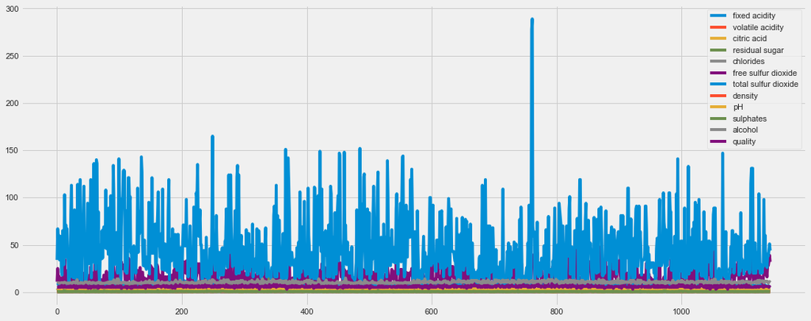

```python
# visualization libraries that go beyond the basics documented here
df.plot(figsize=(17,7))
```

```python
# making Group by

ave_qu = df.groupby("quality").mean()
ave_qu
```

| quality | fixed acidity | volatile acidity | citric acid | residual sugar | chlorides | free sulfur dioxide | total sulfur dioxide | density | pH | sulphates | alcohol |
| --- | --- | --- | --- | --- | --- | --- | --- | --- | --- | --- | --- |
| 3 | 8.450000 | 0.897500 | 0.211667 | 2.666667 | 0.105333 | 8.166667 | 24.500000 | 0.997682 | 3.361667 | 0.550000 | 9.691667 |
| 4 | 7.809091 | 0.700000 | 0.165758 | 2.566667 | 0.094788 | 14.848485 | 40.606061 | 0.996669 | 3.391212 | 0.637879 | 10.260606 |
| 5 | 8.161077 | 0.585280 | 0.240124 | 2.540476 | 0.091770 | 16.612836 | 55.299172 | 0.997073 | 3.302091 | 0.613375 | 9.902277 |
| 6 | 8.317749 | 0.504957 | 0.263680 | 2.444805 | 0.085281 | 15.215368 | 39.941558 | 0.996610 | 3.323788 | 0.676537 | 10.655339 |
| 7 | 8.851049 | 0.393671 | 0.386573 | 2.760140 | 0.075217 | 14.538462 | 37.489510 | 0.996071 | 3.287133 | 0.743566 | 11.482634 |
| 8 | 8.806250 | 0.410000 | 0.432500 | 2.643750 | 0.070187 | 11.062500 | 29.375000 | 0.995553 | 3.240625 | 0.766250 | 11.937500 |

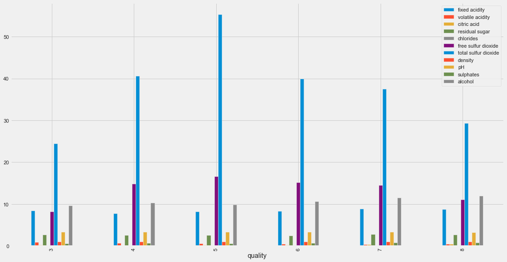

```python
# graph the group by
# Calling a DataFrame’s plot() method with kind='bar' produces a multiple bar plot:

ave_qu.plot(kind="bar",figsize=(17,9))
```

Now we see the effect of the elements on the quality using

Draw a line plot with possibility of several semantic groupings.

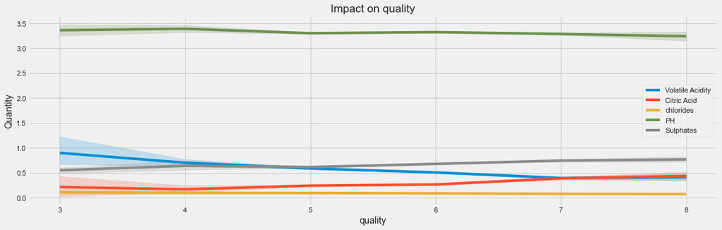

```python
# let see effect some of elements on the quality - details
plt.figure(figsize=(17,5))
sns.lineplot(data=df, x="quality",y="volatile acidity",label="Volatile Acidity")
sns.lineplot(data=df, x="quality",y="citric acid",label="Citric Acid")
sns.lineplot(data=df, x="quality",y="chlorides",label="chlorides")
sns.lineplot(data=df, x="quality",y="pH",label="PH")
sns.lineplot(data=df, x="quality",y="sulphates",label="Sulphates")
plt.ylabel("Quantity")
plt.title("Impact on quality")
plt.legend()
plt.show()
```

Now let's visualize relation between wine features and wine quality Boxplot features against wine quality

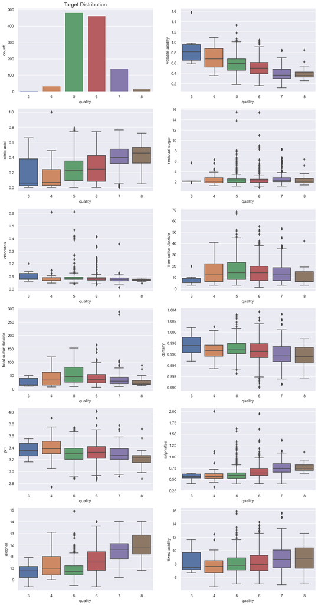

```python
fig,ax=plt.subplots(6,2,figsize=(15,30))
sns.countplot(x=df.quality,ax=ax[0][0]).set_title('Target Distribution',size=15)
sns.boxplot(x=df.quality,y=df['volatile acidity'],ax=ax[0][1])
sns.boxplot(x=df.quality,y=df['citric acid'],ax=ax[1][0])
sns.boxplot(x=df.quality,y=df['residual sugar'],ax=ax[1][1])
sns.boxplot(x=df.quality,y=df['chlorides'],ax=ax[2][0])
sns.boxplot(x=df.quality,y=df['free sulfur dioxide'],ax=ax[2][1])
sns.boxplot(x=df.quality,y=df['total sulfur dioxide'],ax=ax[3][0])
sns.boxplot(x=df.quality,y=df['density'],ax=ax[3][1])
sns.boxplot(x=df.quality,y=df['pH'],ax=ax[4][0])
sns.boxplot(x=df.quality,y=df['sulphates'],ax=ax[4][1])
sns.boxplot(x=df.quality,y=df['alcohol'],ax=ax[5][0])
sns.boxplot(x=df.quality,y=df['fixed acidity'],ax=ax[5][1])
```

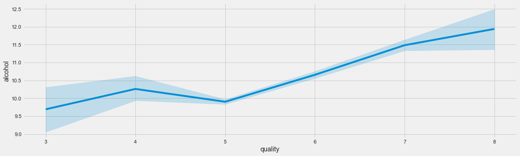

```python
# effect the Alcohol in the quality

plt.figure(figsize=(17,5))
sns.lineplot(data=df, x="quality",y="alcohol")
```

Pairplot important wine characteristics.

To plot multiple pairwise bivariate distributions in a dataset, you can use the pairplot() function. This shows the relationship combination of variable in a DataFrame as a matrix of plots and the diagonal plots are the univariate plots.

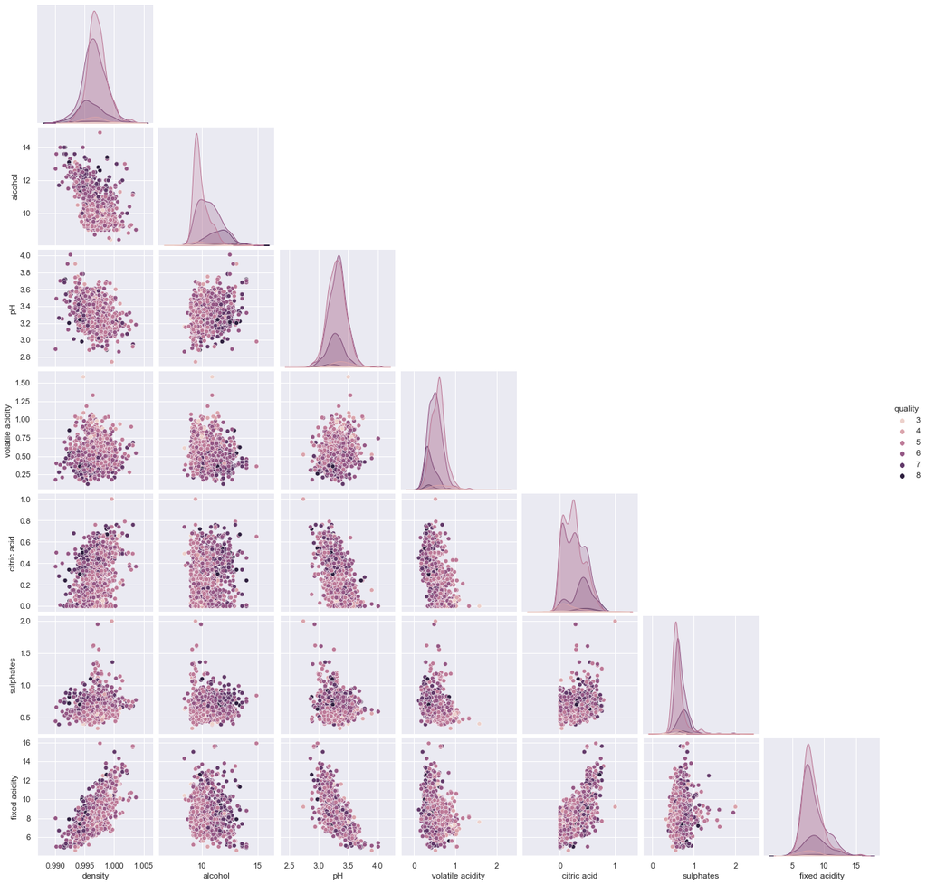

```python
sns.pairplot(df,corner=True, hue='quality',
            x_vars=['density','alcohol','pH','volatile acidity','citric acid','sulphates','fixed acidity'],
            y_vars=['density','alcohol','pH','volatile acidity','citric acid','sulphates','fixed acidity']
            )
```

Analysis Results

If you drink wine, please pay attention to these items.

Target2.

In the second part of wine review, I would like to use the exploratory data analysis of wine reviews given by diffirent customers and tasters across different countries.

```python
import os
os.getcwd()
```

```
'/Users/larisa'
```

```python
import pandas as pd
```

```python
wine_reviews = pd.read_csv('winemag-data.csv', index_col=0)
wine_reviews.head(2)
```

|  | country | description | designation | points | price | province | region_1 | region_2 | taster_name | taster_twitter_handle | title | variety | winery |
| --- | --- | --- | --- | --- | --- | --- | --- | --- | --- | --- | --- | --- | --- |
| 0 | Italy | Aromas include tropical fruit, broom, brimston... | Vulkà Bianco | 87 | NaN | Sicily & Sardinia | Etna | NaN | Kerin O’Keefe | @kerinokeefe | Nicosia 2013 Vulkà Bianco (Etna) | White Blend | Nicosia |
| 1 | Portugal | This is ripe and fruity, a wine that is smooth... | Avidagos | 87 | 15.0 | Douro | NaN | NaN | Roger Voss | @vossroger | Quinta dos Avidagos 2011 Avidagos Red (Douro) | Portuguese Red | Quinta dos Avidagos |

Function Def A simple histogram can be a great first step to analize and understand a dataset. I will start with univariate analysis and after it, I will cross some features by the numerical.

```python
def resumetable(df):
    print(f"Dataset Shape: {df.shape}")
    summary = pd.DataFrame(df.dtypes,columns=['dtypes'])
    summary = summary.reset_index()
    summary['Name'] = summary['index']
    summary = summary[['Name','dtypes']]
    summary['Missing'] = df.isnull().sum().values
    summary['Uniques'] = df.nunique().values
    summary['First Value'] = df.loc[0].values
    summary['Second Value'] = df.loc[1].values
    summary['Third Value'] = df.loc[2].values

    for name in summary['Name'].value_counts().index:
        summary.loc[summary['Name'] == name, 'Entropy'] = round(stats.entropy(df[name].value_counts(normalize=True), base=2),2)

    return summary
```

```python
resumetable(wine_reviews)
```

```
Dataset Shape: (129971, 13)
```

|  | Name | dtypes | Missing | Uniques | First Value | Second Value | Third Value | Entropy |
| --- | --- | --- | --- | --- | --- | --- | --- | --- |
| 0 | country | object | 63 | 43 | Italy | Portugal | US | 2.77 |
| 1 | description | object | 0 | 119955 | Aromas include tropical fruit, broom, brimston... | This is ripe and fruity, a wine that is smooth... | Tart and snappy, the flavors of lime flesh and... | 16.83 |
| 2 | designation | object | 37465 | 37979 | Vulkà Bianco | Avidagos | NaN | 13.83 |
| 3 | points | int64 | 0 | 21 | 87 | 87 | 87 | 3.64 |
| 4 | price | float64 | 8996 | 390 | NaN | 15.0 | 14.0 | 5.77 |
| 5 | province | object | 63 | 425 | Sicily & Sardinia | Douro | Oregon | 5.05 |
| 6 | region_1 | object | 21247 | 1229 | Etna | NaN | Willamette Valley | 7.89 |
| 7 | region_2 | object | 79460 | 17 | NaN | NaN | Willamette Valley | 3.28 |
| 8 | taster_name | object | 26244 | 19 | Kerin O’Keefe | Roger Voss | Paul Gregutt | 3.39 |
| 9 | taster_twitter_handle | object | 31213 | 15 | @kerinokeefe | @vossroger | @paulgwine | 3.23 |
| 10 | title | object | 0 | 118840 | Nicosia 2013 Vulkà Bianco (Etna) | Quinta dos Avidagos 2011 Avidagos Red (Douro) | Rainstorm 2013 Pinot Gris (Willamette Valley) | 16.81 |
| 11 | variety | object | 1 | 707 | White Blend | Portuguese Red | Pinot Gris | 5.67 |
| 12 | winery | object | 0 | 16757 | Nicosia | Quinta dos Avidagos | Rainstorm | 12.98 |

Below you see a very interesting distribution of Points and Price.

We can see that the values of points are distributed between 80 and 100. The price has a high difference between the values and a high standard deviation In prices, the IQR (Interquantil Range - the interquartile range tells you the spread of the middle half of your distribution) is 25. The max value is 3300; We will explore it further later, let's start.

Points Distribution I will start exploring points and after I will see the same on price. Let's see the points distributions and quantiles

```python
print("Statistics of numerical data: ")
print(wine_reviews.describe())
```

```
Statistics of numerical data:
              points          price
count  129971.000000  120975.000000
mean       88.447138      35.363389
std         3.039730      41.022218
min        80.000000       4.000000
25%        86.000000      17.000000
50%        88.000000      25.000000
75%        91.000000      42.000000
max       100.000000    3300.000000
```

Distribution of Wine Reviews. Let's start looking at the distribution of Points and Prices. The function described is focused on numerical features, which in this case are points and price

```python
import pandas as pd #Library to handle with dataframes
import matplotlib.pyplot as plt # Library to plot graphics
import numpy as np # To handle with matrices
import seaborn as sns # to build modern graphics
from scipy.stats import kurtosis, skew # it's to explore some statistics of numerical values
from scipy import stats
```

Points Distribution. I will start exploring points and after I will see the same on price. Let's see the points distributions and quantiles

To define the size of figures that I will build - this will create a grid of 1 row and 2 columns; this is the first graphic seting the seaborn countplot to know the points distribuition, the second one creating a cumulative distribution

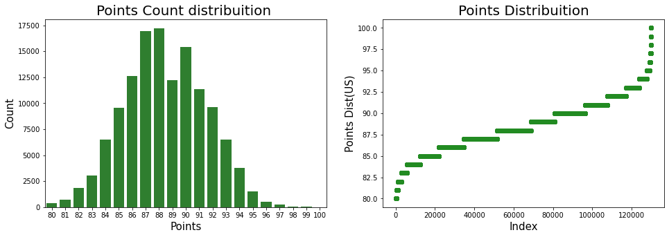

```python
plt.figure(figsize=(16,5))

plt.subplot(1,2,1) # this will create a grid of 1 row and 2 columns; this is the first graphic
g = sns.countplot(x='points', data=wine_reviews, color='forestgreen') # seting the seaborn countplot to known the points distribuition
g.set_title("Points Count distribuition ", fontsize=20) # seting title and size of font
g.set_xlabel("Points", fontsize=15) # seting xlabel and size of font
g.set_ylabel("Count", fontsize=15) # seting ylabel and size of font

plt.subplot(1,2,2)  # this will set the second graphic of our grid
plt.scatter(range(wine_reviews.shape[0]), np.sort(wine_reviews.points.values), color='forestgreen') # creating a cumulative distribution
plt.xlabel('Index', fontsize=15)  # seting xlabel and size of font
plt.ylabel('Points Dist(US)', fontsize=15)  # seting ylabel and size of font
plt.title("Points Distribuition", fontsize=20) # seting title and size of font

plt.show() #rendering the graphs
```

We can clearly see the distribution of the data. It seems very similar with a normal distribution.

Just a few numbers of wines have less than 82 points and more than 95 points. As Points are one of the most important metrics in this dataset, I will explore it further more.

Country average wine price - the average price of wine in 'Switzerland' is highest.

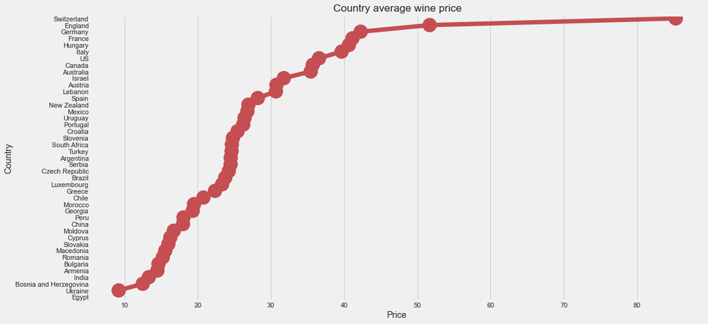

```python
cnt = wine_reviews.groupby(['country',]).mean()['price'].sort_values(ascending=False).to_frame()

plt.figure(figsize=(16,8))
sns.pointplot(x = cnt['price'] ,y = cnt.index ,color='r',orient='h',markers='o')
plt.title('Country average wine price')
plt.xlabel('Price')
plt.ylabel('Country');
```

Average rating of wine by country. Points: The number of points Wine Testers rated the wine on a scale of 1-100 (though they say they only post reviews for wines that score >=80)

Very meaningful scatter plot.

The highest prices aren't of the wine with highest pontuation. The most expensive wine has ponctuation between 87 and 90. Maybe it would be interesting to build an recommender system to find cheapest wines with the same quality.

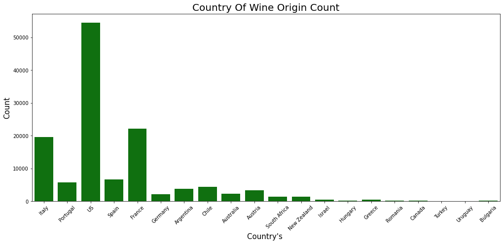

```python
plt.figure(figsize=(17,7))

country = wine_reviews.country.value_counts()[:20]

g = sns.countplot(x='country',
                  data=wine_reviews[wine_reviews.country.isin(country.index.values)],
                 color='green')
g.set_title("Country Of Wine Origin Count", fontsize=20)
g.set_xlabel("Country's ", fontsize=15)
g.set_ylabel("Count", fontsize=15)
g.set_xticklabels(g.get_xticklabels(),rotation=45)

plt.show()
```

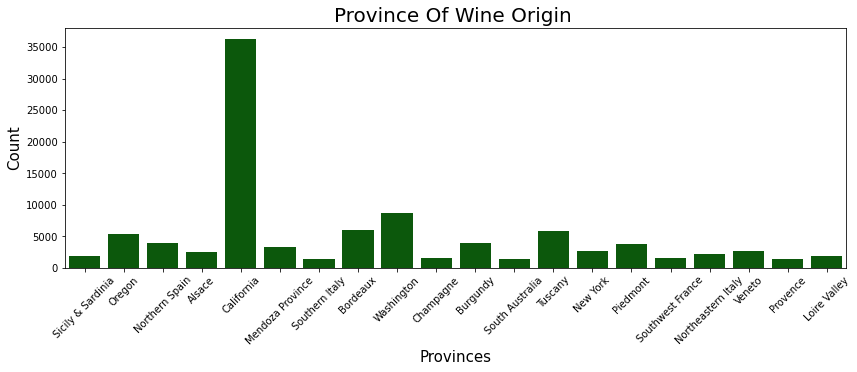

```python
plt.figure(figsize=(14,15))

provinces = wine_reviews['province'].value_counts()[:20]

plt.subplot(3,1,1)
g = sns.countplot(x='province',
                  data=wine_reviews[wine_reviews.province.isin(provinces.index.values)],
                  color='darkgreen')
g.set_title("Province Of Wine Origin ", fontsize=20)
g.set_xlabel("Provinces", fontsize=15)
g.set_ylabel("Count", fontsize=15)
g.set_xticklabels(g.get_xticklabels(),rotation=45)


plt.show()
```

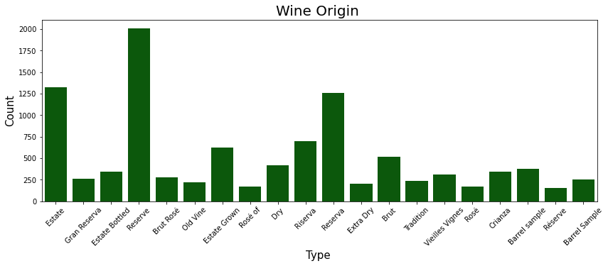

```python
plt.figure(figsize=(14,16))

designation = wine_reviews.designation.value_counts()[:20]

plt.subplot(3,1,1)
g = sns.countplot(x='designation',
                  data=wine_reviews.loc[(wine_reviews.designation.isin(designation.index.values))],
                  color='darkgreen')
g.set_title("Wine Origin ", fontsize=20)
g.set_xlabel("Type ", fontsize=15)
g.set_ylabel("Count", fontsize=15)
g.set_xticklabels(g.get_xticklabels(),rotation=45)

plt.show()
```

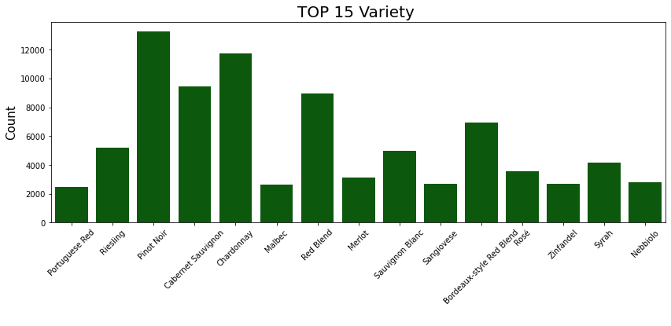

```python
plt.figure(figsize=(14,16))

variety = wine_reviews.variety.value_counts()[:15]

plt.subplot(3,1,1)
g = sns.countplot(x='variety',
                  data=wine_reviews.loc[(wine_reviews.variety.isin(variety.index.values))],
                  color='darkgreen')
g.set_title("TOP 15 Variety ", fontsize=20)
g.set_xlabel(" ", fontsize=15)
g.set_ylabel("Count", fontsize=15)
g.set_xticklabels(g.get_xticklabels(),rotation=45)

plt.show()
```

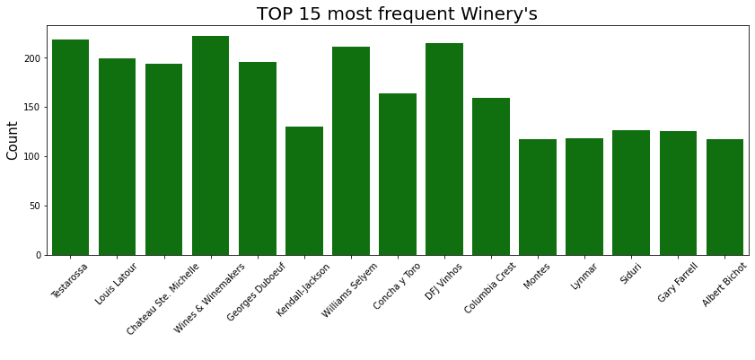

```python
plt.figure(figsize=(14,16))

winery = wine_reviews.winery.value_counts()[:15]

plt.subplot(3,1,1)
g = sns.countplot(x='winery',
                  data=wine_reviews.loc[(wine_reviews.winery.isin(winery.index.values))],
                  color='green')
g.set_title("TOP 15 most frequent Winery's", fontsize=20)
g.set_xlabel(" ", fontsize=15)
g.set_ylabel("Count", fontsize=15)
g.set_xticklabels(g.get_xticklabels(),rotation=45)

plt.show()
```

We can see that some wineries have +- 200 labels in his portfolio's.

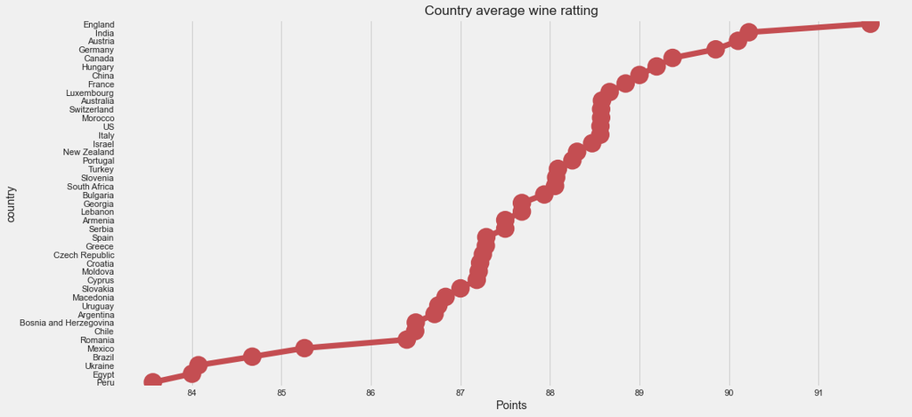

```python
cnt = wine_reviews.groupby(['country',]).mean()['points'].sort_values(ascending=False).to_frame()

plt.figure(figsize=(16,8))
sns.pointplot(x = cnt['points'] ,y = cnt.index ,color='r',orient='h')
plt.title('Country average wine ratting')
plt.xlabel('Points');
```

The average rating of wine for England is top in the table. The countries like Austria, Germany, India, France are top quality wine producing countries.

Relation between Price and Points

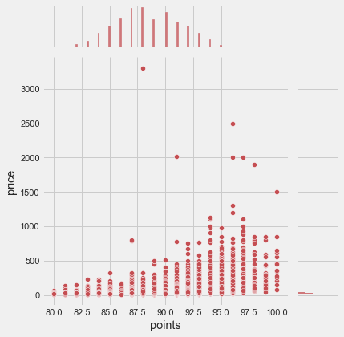

```python
sns.jointplot( x = wine_reviews['points'],y = wine_reviews['price'],color='r');
```

Top most wine by variety Variety: the type of grapes used to make the wine

Designation

The vineyard within the winery where the grapes that made the wine are from. A vineyard is a plantation of grape-bearing wines, grown mainly for winemaking, but also raisins, table grapes and non-alcoholic grape juice. The science, practice and study of wineyard production is known as viticulture Winery A Winery is a building or property that produces wine, or a business involved in the production of wine, such as a wine company.

Province The province or state that the wine is from

Region1 The wine growing area in a province or state

```python
cnt = wine_reviews.groupby(['country','province','points','region_1',])['price'].agg(
    ['count','min','max','mean']).sort_values(by = 'mean',ascending = False)[:5]
cnt.reset_index(inplace = True)
cnt.style.highlight_max()
```

|  | country | province | points | region_1 | count | min | max | mean |
| --- | --- | --- | --- | --- | --- | --- | --- | --- |
| 0 | France | Burgundy | 96 | La Romanée | 2 | 2000.000000 | 2500.000000 | 2250.000000 |
| 1 | France | Bordeaux | 100 | Pauillac | 1 | 1500.000000 | 1500.000000 | 1500.000000 |
| 2 | France | Bordeaux | 100 | Saint-Émilion | 1 | 1500.000000 | 1500.000000 | 1500.000000 |
| 3 | France | Bordeaux | 98 | Margaux | 2 | 380.000000 | 1900.000000 | 1140.000000 |
| 4 | France | Burgundy | 94 | La Romanée | 1 | 1125.000000 | 1125.000000 | 1125.000000 |

```python
print('Number of reqion2: ',wine_reviews['region_2'].nunique())
print('Null values in reqion2: ',wine_reviews['region_2'].isnull().sum())
cnt = wine_reviews.groupby(['country','province','region_1','region_2','points'])['price'].agg(
    ['count','min','max','mean']).sort_values(by = 'mean',ascending = False)[:5]
cnt.reset_index(inplace=True)
cnt.style.set_table_styles([{'selector': 'tr:hover','props': [('background-color', 'yellow')]}])
```

```
Number of reqion2:  17
Null values in reqion2:  79460
```

|  | country | province | region_1 | region_2 | points | count | min | max | mean |
| --- | --- | --- | --- | --- | --- | --- | --- | --- | --- |
| 0 | US | California | Sonoma County | Sonoma | 100 | 1 | 450.000000 | 450.000000 | 450.000000 |
| 1 | US | California | Sonoma County | Sonoma | 97 | 2 | 450.000000 | 450.000000 | 450.000000 |
| 2 | US | California | Sonoma County | Sonoma | 96 | 1 | 450.000000 | 450.000000 | 450.000000 |
| 3 | US | California | Napa Valley | Napa | 98 | 4 | 85.000000 | 625.000000 | 308.750000 |
| 4 | US | California | Sonoma County | Sonoma | 98 | 1 | 300.000000 | 300.000000 | 300.000000 |

```python
import pandas as pd
```

```python
import os
os.getcwd()
```

```
'/Users/larisa'
```

[figure not shown]

[figure not shown]

```python
# Tableau Story"WineQuality" is attached.
```

```python
import plotly.express as px
country_data = px.data.gapminder()
country_data.tail()
```

|  | country | continent | year | lifeExp | pop | gdpPercap | iso_alpha | iso_num |
| --- | --- | --- | --- | --- | --- | --- | --- | --- |
| 1699 | Zimbabwe | Africa | 1987 | 62.351 | 9216418 | 706.157306 | ZWE | 716 |
| 1700 | Zimbabwe | Africa | 1992 | 60.377 | 10704340 | 693.420786 | ZWE | 716 |
| 1701 | Zimbabwe | Africa | 1997 | 46.809 | 11404948 | 792.449960 | ZWE | 716 |
| 1702 | Zimbabwe | Africa | 2002 | 39.989 | 11926563 | 672.038623 | ZWE | 716 |
| 1703 | Zimbabwe | Africa | 2007 | 43.487 | 12311143 | 469.709298 | ZWE | 716 |

```python
px.scatter_geo
```

```python
map_fig = px.scatter_geo(country_data,
                        locations = 'iso_alpha',
                        projection = 'orthographic',
                        color = 'continent',
                        opacity = .8,
                        hover_name = 'country',
                        hover_data = ['lifeExp', 'pop']
                        )
map_fig.show()
```

[output not shown]